# Discrete Data Analysis: A Friendly Guide to Visualising Categorical Data for Machine Learning Practitioners, with Examples in R

The vcd package contains a specialised fourfold plot whose purpose is to compare several $2 \times 2$ tables over the levels of a third feature. It is intended for a different purpose than what we want to do, but the behaviour can be easily changed with a parameter to the plot function call that makes it perfectly suited for our needs.

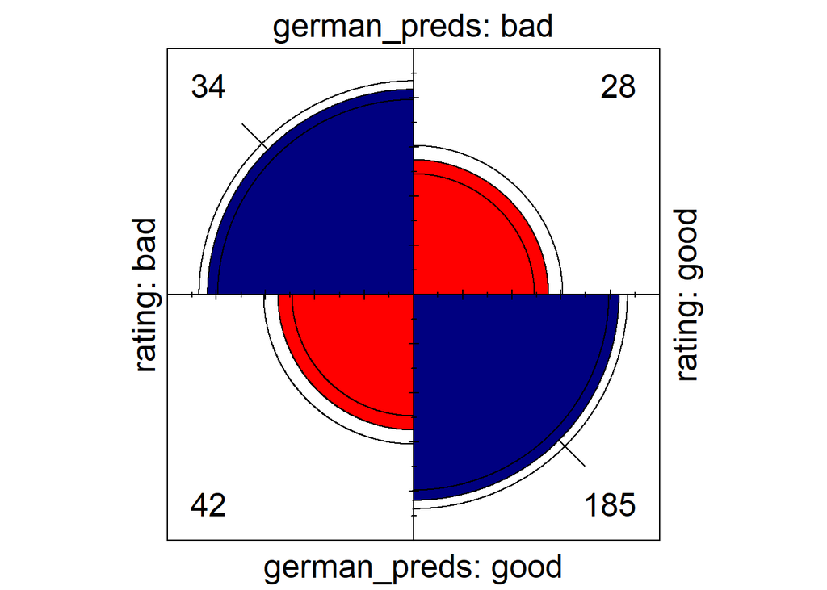

```r
# fourfold plot preserves the table structure it was given
# however, default balances the areas to compare odds ratios no matter the individual count values
# that's not what we want
fourfold(confmat)
```

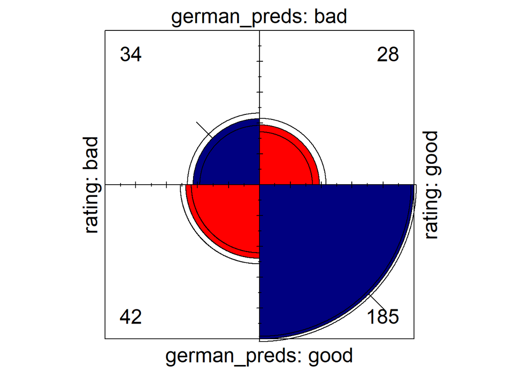

```r
# std = "all.max" suppresses balancing the areas
# behaves like a rose plot
fourfold(confmat, std = "all.max")
```

The rose plot makes it visually clear that the model is great a classifying true negatives, but is predicting too many negatives over all and misclassifying more true prositives than it correctly identifies. Such a high FNR is not acceptable. Why is the model not doing well?

If a categorical feature $c$ has a high importance, it would suggest that the model has encoded how the ratio of *good* and *bad* ratings is different over the different levels of $c$ and can make use of that information in predicting.

Let’s use feature importance to break down the results. This data set had a mix of numeric and categorical features.

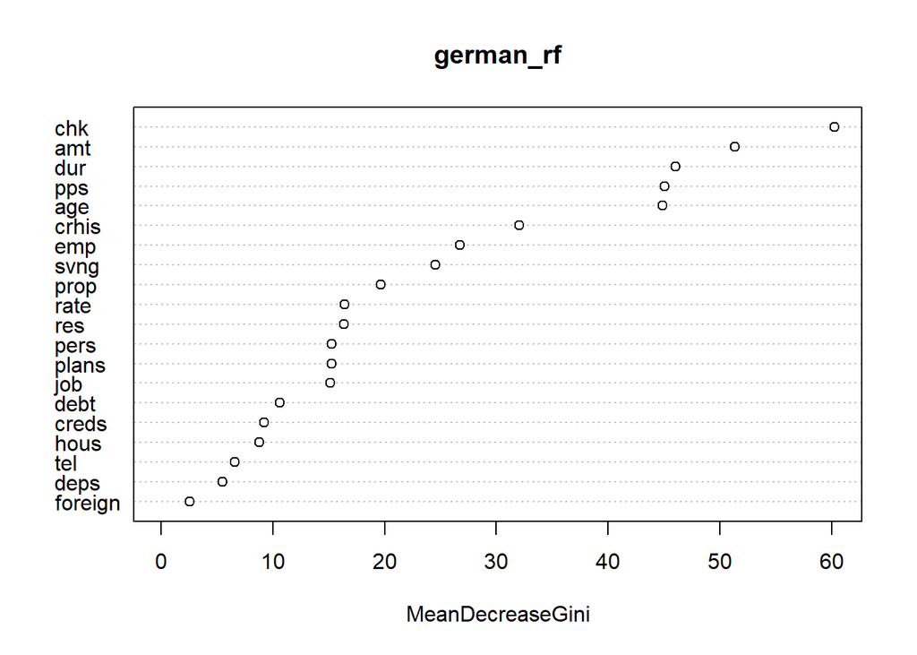

```r
varImpPlot(german_rf)
```

First thing to note is that there is no elbow point where we could safely make the model simpler by just picking the top performing features.

Secondly, and very fortunately for us, several categorical features are considered important, including the top one. Three of them are in the top six. Of course, it doesn’t matter if categorical variables don’t have high importance. Any numeric variable could be binned/discretised, and then have this technique applied.

As we want to customise the fourfold plot a little, we can make a new function to save repeating the code each time.

```r
# customise the fourfold plot
my_rose <- function(cm) {
  fourfold(cm
         , std = "all.max" # mimic a 4 way rose plot
         , conf_level = 0 # suppress confint tests, not useful here
         , color = c("#FF0000", "#000080") # need to force colours due to suppressing confint test
         )
}

# while we're at it, let's make a function to get the numeric statistics that we want from the conf mat
my_confmat_stats <- function(cm) {
  cf_stats <- list()
  for (i in 1:(dim(cm)[3])) {

    category <- dimnames(cm)[[3]][i]
    acc <- sum(diag(cm[ , , i]))/sum(cm[ , , i])

    # False Negative Rate FN / (TP + FN)
    fnr <- cm[2, 1, i]/sum(cm[ , 1, i])

    # False Ommision Rate FN / (TN + FN)
    fomr <- cm[2, 1, i]/sum(cm[2, , i])

    # collect
    cf_stats[[category]] <-
      c(acc=acc, fnr=fnr, fomr=fomr)
  }

  return(t(as.data.frame(cf_stats)))
}
```

We’ll now make rose plots of the confusion matrix, stratified by the top categorical features. Try to relate the numeric stats to the patterns in the plots.

```r
# stratify the conf mat by chk
confmat_c <- with(german_test
                  , table(german_preds
                          , rating
                          , chk))

# view the stats then plot
my_confmat_stats(confmat_c)
```

```
##           acc       fnr      fomr
## A11 0.6777778 0.3333333 0.2708333
## A12 0.6212121 0.6363636 0.2978723
## A13 0.8421053 1.0000000 0.1111111
## A14 0.8859649 1.0000000 0.1140351
```

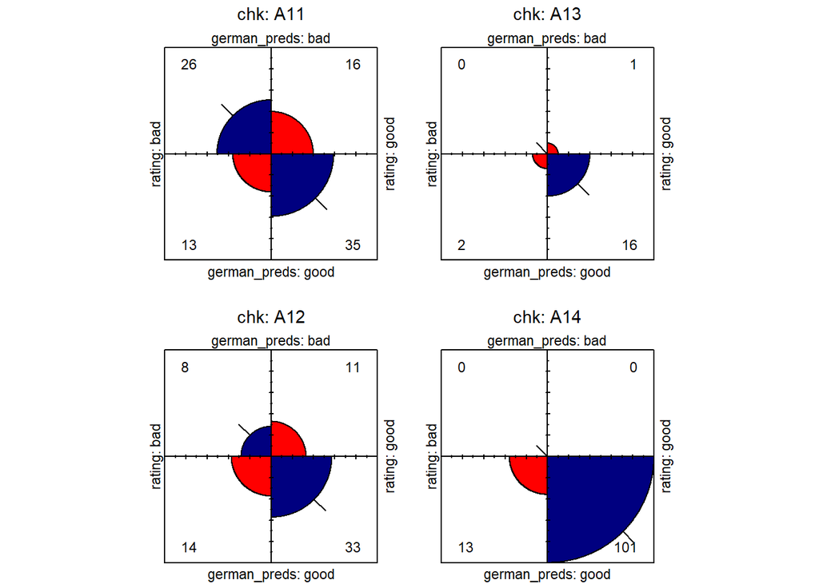

```r
my_rose(confmat_c)
```

We now proceed with the next two most important categorical features, but leave any further diagnostics as talking points.

```r
confmat_p <- with(german_test
                  , table(german_preds
                          , rating
                          , pps))

my_confmat_stats(confmat_p)
```

```
##            acc       fnr      fomr
## A40  0.7702703 0.4166667 0.1886792
## A41  0.7619048 0.7500000 0.1666667
## A410 0.5000000       NaN 0.0000000
## A42  0.6530612 0.8461538 0.2682927
## A43  0.8409091 0.4705882 0.1095890
## A44  0.5000000 1.0000000 0.5000000
## A45  0.6000000 1.0000000 0.4000000
## A46  0.7058824 0.3750000 0.3000000
## A48  1.0000000       NaN 0.0000000
## A49  0.7200000 0.5000000 0.1666667
```

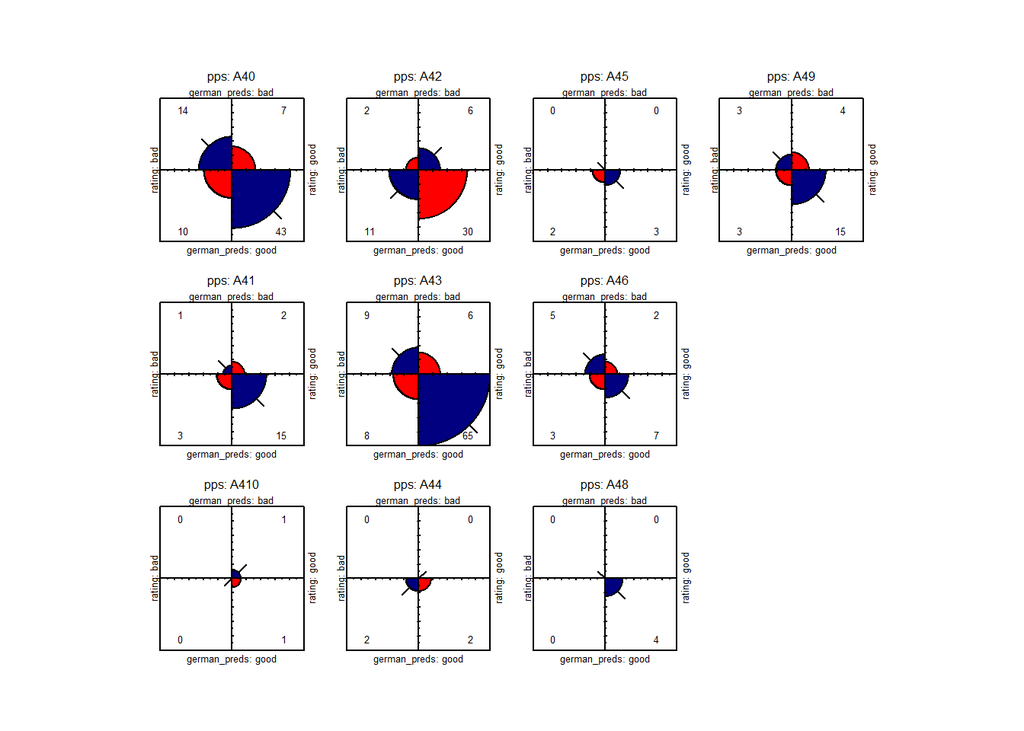

```r
my_rose(confmat_p)
```

```r
confmat_h <- with(german_test
                  , table(german_preds
                          , rating
                          , crhis))

my_confmat_stats(confmat_h)
```

```
##           acc       fnr      fomr
## A30 0.8000000 0.0000000 0.0000000
## A31 0.7142857 0.4000000 0.2222222
## A32 0.7152318 0.5909091 0.2241379
## A33 0.7916667 0.2000000 0.0625000
## A34 0.8222222 0.8125000 0.1547619
```

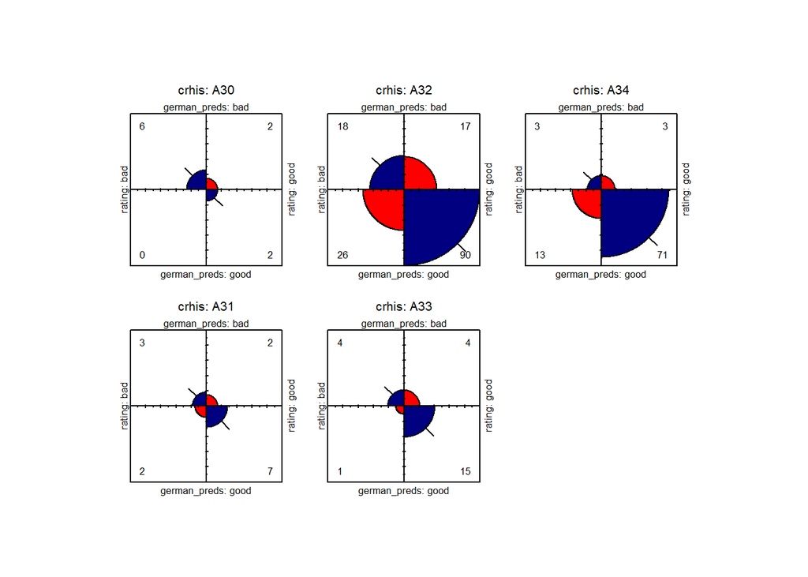

```r
my_rose(confmat_h)
```

```r
confmat_e <- with(german_test
                  , table(german_preds
                          , rating
                          , emp))

my_confmat_stats(confmat_e)
```

```
##           acc       fnr       fomr
## A71 0.5714286 0.8000000 0.36363636
## A72 0.7674419 0.5000000 0.24242424
## A73 0.7019231 0.7037037 0.22619048
## A74 0.7777778 0.2222222 0.05405405
## A75 0.8513514 0.4736842 0.14516129
```

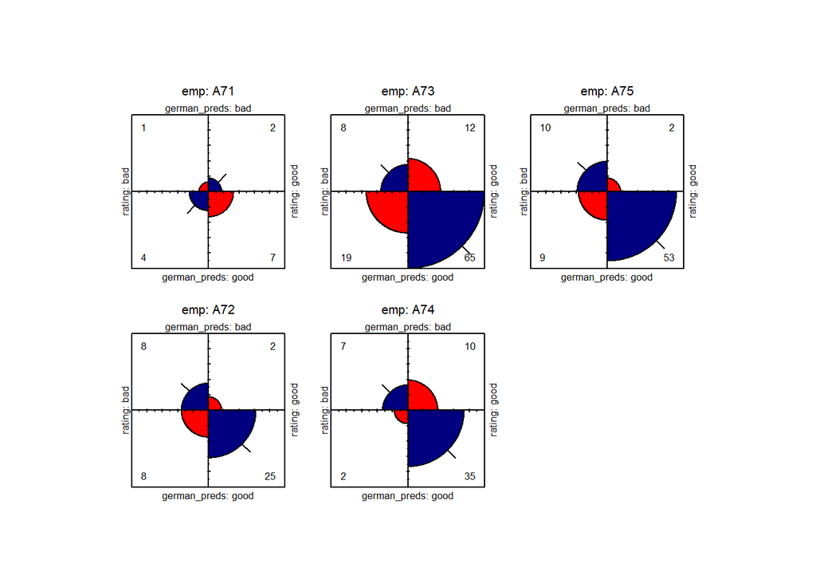

```r
my_rose(confmat_e)
```

The *dur* feature is integer valued, with 22 unique levels. This technique scales usefully even up to this number of strata! While the exact details would take some time to analyse fully, there are obvious visible patterns.

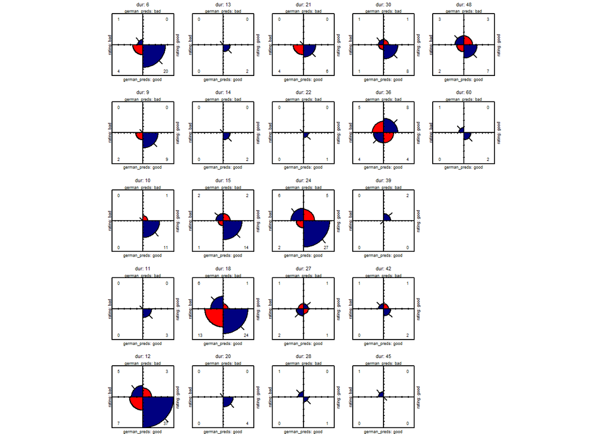

```r
confmat_d <- with(german_test
                  , table(german_preds
                          , rating
                          , dur))
my_rose(confmat_d)
```

This technique can be scaled to more dimensions, with some sacrifices, using log odds ratios. It is a little less intuitive at first, but can be very useful once you have a clear understanding of that the log odds ratio is telling you.

Recall from the introduction how this statistic was defined. The formula can be rearranged such that

$$\phi = \frac{\mathrm{TP} \times \mathrm{TN}}{\mathrm{FP} \times \mathrm{FN}}$$

The log odds ratio, therefore is larger as the model becomes more accurate. A model that does no better than a random guess has a log odds ratio that is not significantly different from zero. *Note, this approach is not robust to very unbalanced classes.*

A the log odds ratio of a stratified confidence matrix can easily be plotted to see which categories of the stratifying factor provide better accuracy. This will scale up to two additional dimensions, using position, colour and plot character. Such plots are be challenging to interpret and only works well if the features have two or three levels each at the most. However, under those circumstances, interesting interactions may be revealed.

*Note, all the following plots are suppressing the confidence interval. The reason for this is that the data set is rather small and slicing along multiple dimensions results in low counts. Large standard errors can dominate the plot.*

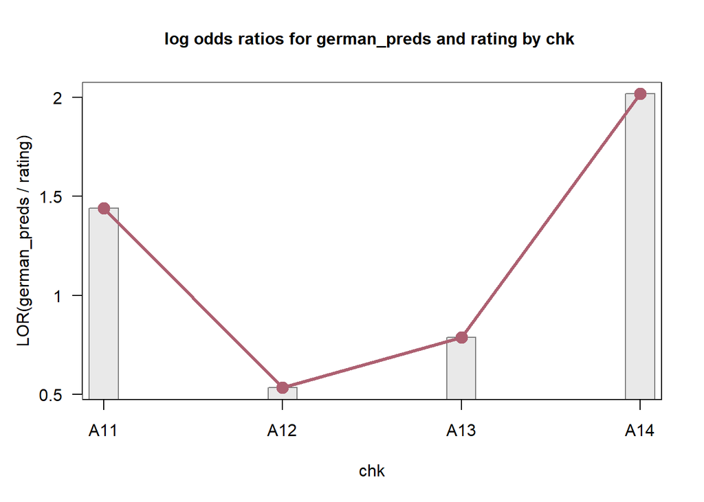

```r
plot(loddsratio(confmat_c), confidence = FALSE)
```

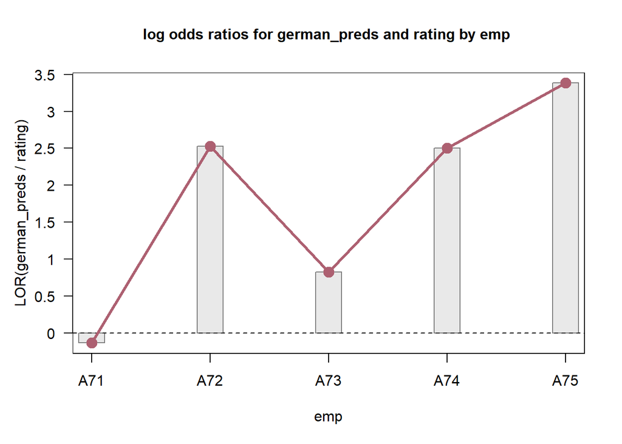

```r
plot(loddsratio(confmat_e), confidence = FALSE)
```

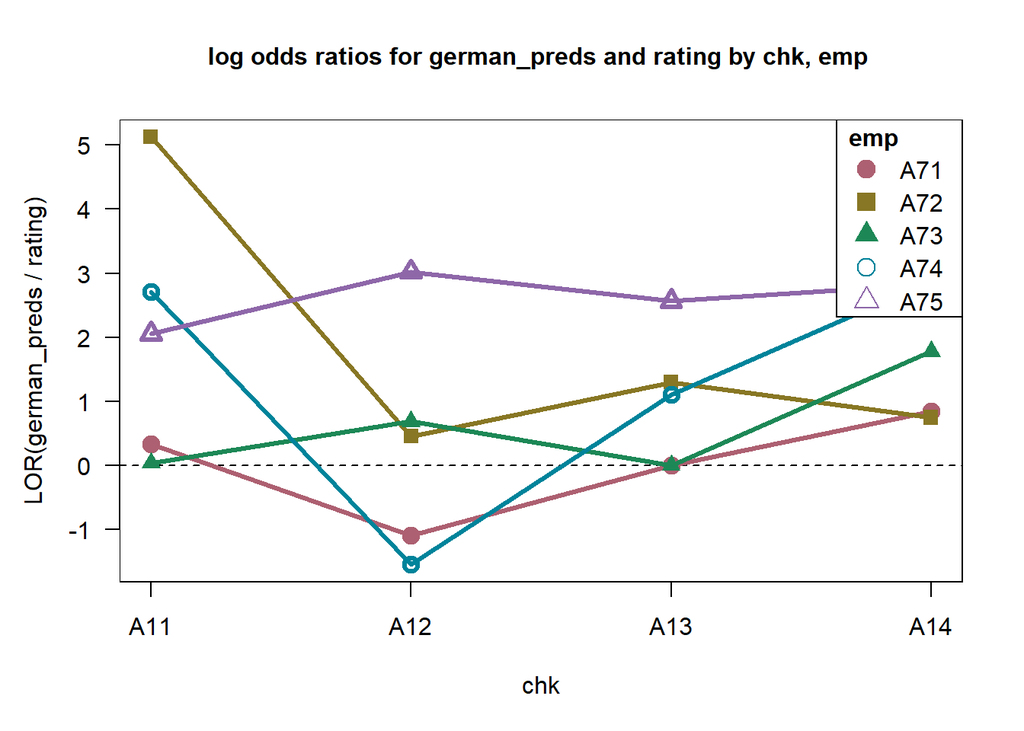

```r
# higher dimensional
confmat_ce <- with(german_test
                   , table(german_preds
                           , rating
                           , chk
                           , emp))

confmat_ce <- with(german_test
                   , table(german_preds
                           , rating
                           , chk
                           , emp))
plot(loddsratio(confmat_ce), confidence = FALSE)
```

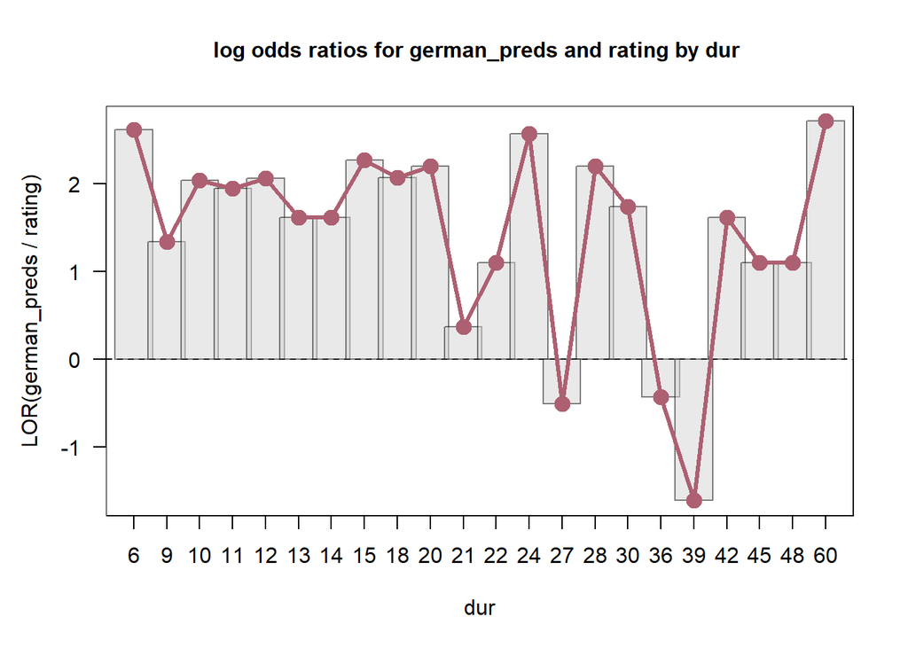

```r
# back to one stratum, but many levels
plot(loddsratio(confmat_d), confidence = FALSE)
```

### 3.3.4 Talking Points

- How would you diagnose the patterns in the further rose plots above?
- Can you determine any interesting interactions between *chk* and *emp* from the log odds ratio plots?
- How could you use information from the stratified confusion matrices to improve the model?
- How could you use this information to improve the model?
- Can you think of other ways to use this information?

## 3.4 Task: Analysing a Confusion Matrix for Ordinal Classification

### 3.4.1 What is this for?

In Machine Learning, the standard way to assess the quality of a supervised classification model is with a confusion matrix. This is a two way table comparing True and Predicted class labels. If you are trying to classify ordered labels, the relationship between the labels matters. Standard accuracy measures penalise near disagreements as if they were full errors. This leads to accuracy estimates that are far too conservative; You might throw out a fairly good model, when there is a good chance you can improve it.

The ratio of class 1 : class 2 is 9:1. Predict every instance as class 1 and you will get 90% accuracy. This not a useful result!

So we use Cohen’s $\kappa$ statistic to weight according to the occurrence of each class in the data. $\kappa = 1$ means perfect agreement while $\kappa = 0$ means no better than chance agreement. The above example would score $\kappa = 0$.

That’s all well and good, but what class labels are related to each other by a natural order such as [*least, middle, most*] then you have an additional complication. You want your model to predict as well as possible, but to make an off-by-one error isn’t as bad as a full opposite error. Also, the classification distribution might be biased, giving different skew and kurtosis (flattened or polarised) by the predictive model.

If you can detect this kind of bias, you can correct it! This is where agreement plots can help. They are based on statistical techniques for comparing two raters, such as two doctors, two film critics, two wine critics etc, to validate ratings and analyse these kinds of bias.

### 3.4.2 When would I use this?

After training an ordinal classification model, when you want to evaluate its performance.

### 3.4.3 Case Study: Comparing Inter-Rater Agreement for Severity of Multiple Sclerosis.

In the following example we compare two sets of diagnoses for the same patients suspected of suffering from Multiple Sclerosis. The diagnoses were made by two neurologists, one in Winnipeg and the other in New Orleans:

1. Certain
2. Probable
3. Possible
4. Doubtful

```r
# combine results from two cities (same raters are involved in all cases)
MSP <- margin.table(MSPatients, 1:2)
```

On this dataset, we can’t say which is the true and which is predicted because they’re both independent raters, but for now let’s assume that Winnipeg Neurologist is the true class and New Orleans Neurologist is the predicted class. The highest accuracy we could expect to get with constant model that always makes the same rating is the proportion of the majority true class. This would give a score of $\kappa = 0$:

```r
margin.table(MSP, 2)
```

```
## Winnipeg Neurologist
##  Certain Probable Possible Doubtful
##       95       66       22       35
```

```r
props <- prop.table(margin.table(MSP, 2))
props
```

```
## Winnipeg Neurologist
##   Certain  Probable  Possible  Doubtful
## 0.4357798 0.3027523 0.1009174 0.1605505
```

```r
# The baseline accuracy is
props[which(props == max(props))]
```

```
##   Certain
## 0.4357798
```

Without looking at the confusion matrix, let’s take a naive look at the accuracy:

```r
# basic accuracy
sum(diag(MSP))/sum(MSP)
```

```
## [1] 0.4449541
```

On the face of it, this looks like a terrible result! Is New Orleans Neurologist just predicting the most frequent Winnipeg class?

```r
MSP
```

```
##                        Winnipeg Neurologist
## New Orleans Neurologist Certain Probable Possible Doubtful
##                Certain       43        8        0        1
##                Probable      36       22        7        0
##                Possible      12       27        8       10
##                Doubtful       4        9        7       24
```

There are definitely some problems with the inter-rater agreement but it doesn’t look like random guessing. Why is accuracy so low? Does class imbalance play a part? What is the $\kappa$ score?

```r
# cohen's kappa - the function in the vcd package provides weights and confidence intervals for this statistic
confint(Kappa(MSP, weights = "Fleiss-Cohen"))
```

```
##
## Kappa              lwr       upr
##   Unweighted 0.1728083 0.3411072
##   Weighted   0.4987456 0.6785713
```

Unweighted $\kappa$, the standard measure, also shows that this is not a very good result.

However, Fleiss-Cohen Weighted $\kappa$ favours near disagreements and taking this into account gives a much better result. Off-by-n errors appear to be common, so these raters are closer than it first appears.

An agreement plot is the best way to visualise a situation like this because it shows how off-by-n errors and other bias could be affecting the outcome.

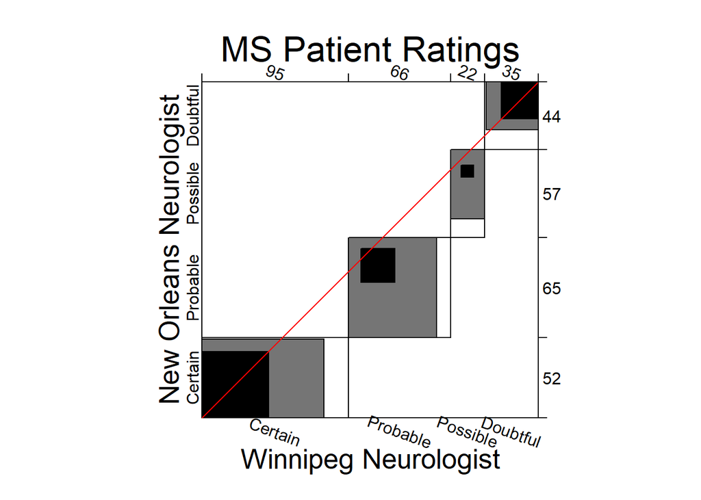

```r
op <- par(mar = c(4, 3, 4, 1) + .1)
B <- agreementplot(MSP
                   , main = "MS Patient Ratings"
                   , xlab_rot = -20
)
```

This plot needs some explaining. The rectangle outlines show the maximum possible agreement, given the marginal totals. The black rectangles indicate where there is full agreement between raters. The shaded area indicates the off by $n$ disagreement. *Note, if there were more categories, there would be more grades of shading*.

Ideally, we want the black area to fill the outline and it’s not very close in this chart. However, the shaded area is coming much closer to filling the available space.

```r
unlist(B)[1 : 2]
```

```
##          Bangdiwala Bangdiwala_Weighted
##           0.2472555           0.7503234
```

The Bangdiwala statistic is calculated based on the ratio of these shaded rectangles to the maximal outline. The large interval between the weighted and unweighted statistics shows that near disagreements are very common and if taken into account, they indicate a much better alignment than was indicated by a naive accuracy measure and even $\kappa$.

With a little intervention, guided by this information, these two raters could become much better aligned.

### 3.4.4 Talking Points

- What other statistics, tools and techniques can you use to analyse a confusion matrix?
- Have you worked with, or can you think of an ordinal classification problem?
- How could you use the Bangdiwala statistic *during* training to improve alignment?

## 3.5 Task: 1-way analysis (goodness of fit) for monitoring the frequency of events.

Count, or frequency data has many varied applications from event monitoring to text analysis. 1-way analysis uses distributions to compare different samples, and monitor for changes in event frequency.

For the first task we will look at two common distributions for count data and compare two samples.

The Poisson distribution has just one parameter $\lambda$ for the rate, and both the mean and variance are equal to this parameter.

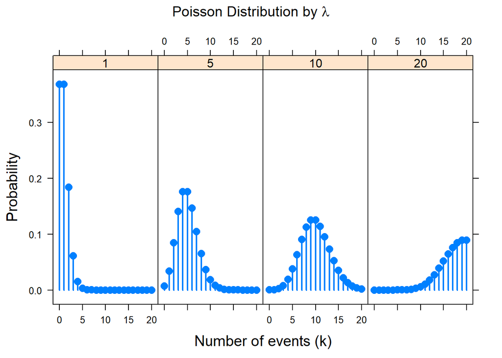

```r
set.seed(12345)

KL <- expand.grid(k = 0 : 20, lambda = c(1, 5, 10, 20))
pois_df <- data.frame(KL, prob = dpois(KL$k, KL$lambda))
pois_df$lambda = factor(pois_df$lambda)

xyplot(prob ~ k | lambda, data = pois_df,
       type = c("h", "p"), pch = 16, lwd = 2
       , cex = 1.25, layout = c(4, 1)
       , main = expression(paste("Poisson Distribution by ", lambda))
       , xlab = list("Number of events (k)", cex = 1.25)
       , ylab = list("Probability", cex = 1.25))
```

The negative binomial distribution has two parameters, rate (size) and dispersion ($\frac{1}{\mathrm{prob}}$). The mean is equal to the rate, but the variance is always greater than the rate. It can appear as a right skewed Poisson distribution and behaves as if a Poisson distribution is being sampled over a period of time while the rate is non-constant.

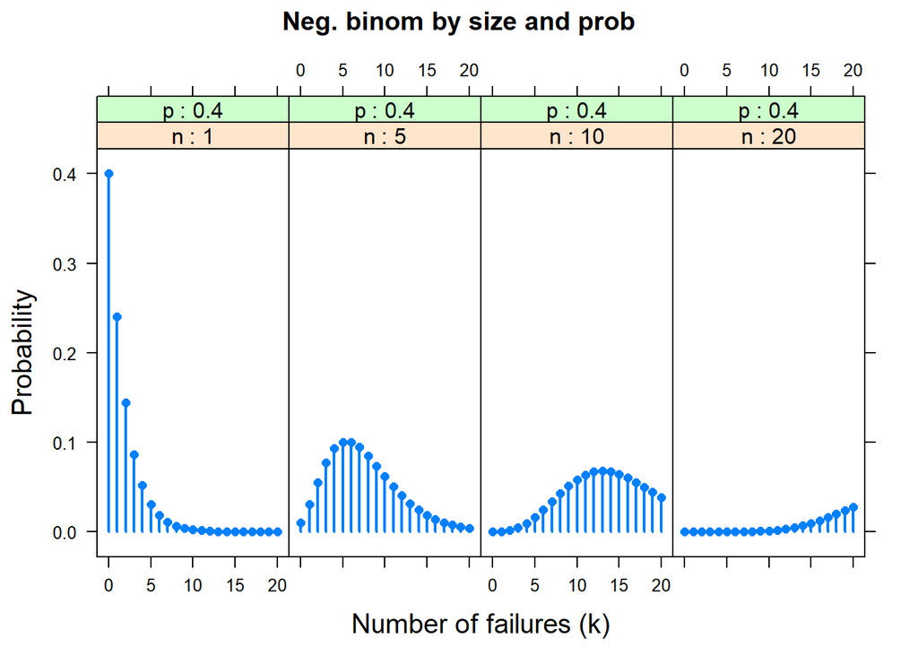

```r
XN <- expand.grid(k = 0 : 20, n = c(1, 5, 10, 20), p = c(0.4, 0.2))
nbin_df <- data.frame(XN, prob = dnbinom(XN$k, XN$n, XN$p))
nbin_df$n <- factor(nbin_df$n)
nbin_df$p <- factor(nbin_df$p)

xyplot(prob ~ k | n + p, data = subset(nbin_df, p == 0.4)
       , main = "Neg. binom by size and prob"
       , xlab = list("Number of failures (k)", cex = 1.25)
       , ylab = list("Probability",  cex = 1.25)
       , type = c("h", "p"), pch = 16, lwd = 2
       , strip = strip.custom(strip.names = TRUE)
)
```

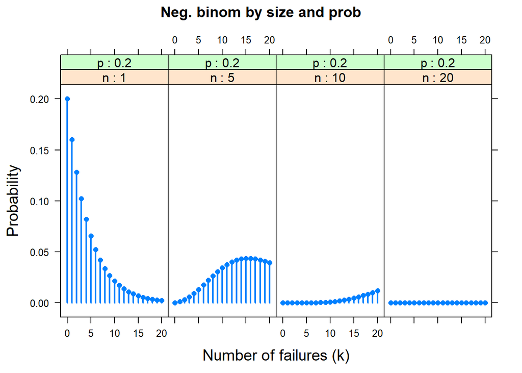

```r
xyplot(prob ~ k | n + p, data = subset(nbin_df, p == 0.2)
       , main = "Neg. binom by size and prob"
       , xlab = list("Number of failures (k)", cex = 1.25)
       , ylab = list("Probability",  cex = 1.25)
       , type = c("h", "p"), pch = 16, lwd = 2
       , strip = strip.custom(strip.names = TRUE)
)
```

However, Poisson and negative binomial data can look very similar. Identifying the best match and estimating the parameters is essential for accurate event monitoring and reporting results.

### 3.5.1 Case Study in Text Analysis: Marker word frequency

The following technique has been used to determine if documents are written by same or different authors. Distributions of marker words are fit to text that is known to come from one author.

Any previously unseen text can then be tested against these known distributions to determine if they are written by the same author.

In this simple case study, we will use the Federalist dataset to analyse how many times the word ‘may’ appear per 200 word block. This is a marker word, that could help identify an author by how often they use it. Most studies of this kind would compare results across many such tests with different words.

Notes:

- The rate is occurrences/200 words.
- The expected count is the rate parameter $\times$ 200
- Plotting the square root transformation of the frequency provides more detail on the small numbers in the right tail of these charts. Log transformation would also work but the rootogram visualisations use square root transformation by default. So, this is also applied manually where necessary for comparison.

```r
data("Federalist", package = "vcd")
Federalist
```

```
## nMay
##   0   1   2   3   4   5   6
## 156  63  29   8   4   1   1
```

```r
sum(Federalist) # number of blocks
```

```
## [1] 262
```

```r
sum(expand.dft(as.data.frame(Federalist))$nMay) # number of occurences
```

```
## [1] 172
```

```r
mean(expand.dft(as.data.frame(Federalist))$nMay)
```

```
## [1] 0.6564885
```

```r
var(expand.dft(as.data.frame(Federalist))$nMay)
```

```
## [1] 1.007985
```

The descriptive stats showed a slightly higher variance but we don’t know if this is significant. What’s the right test to use here?

A very naive approach is to take the mean and visually compare a Poisson distribution with this value for $\lambda$ against the actual data.

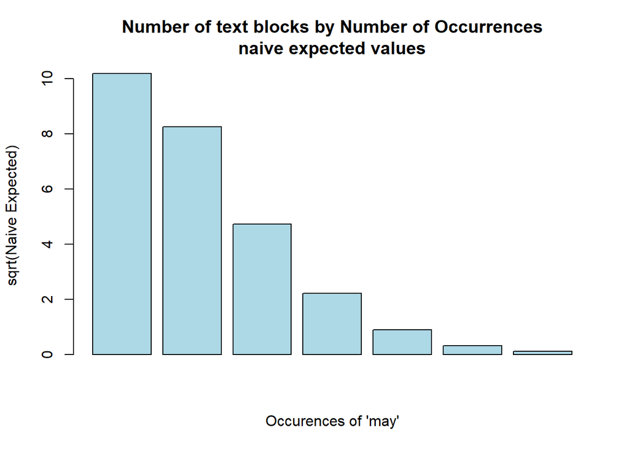

```r
barplot(sqrt(200 * dpois(0:6, mean(expand.dft(as.data.frame(Federalist))$nMay)
))
        , main = "Number of text blocks by Number of Occurrences\nnaive expected values"
        , ylab = "sqrt(Naive Expected)"
        , xlab = "Occurences of 'may'"
        , col = "lightblue")
```

The actual data looks a bit like this distribution. Could this be a good fit? How can we easily compare them?

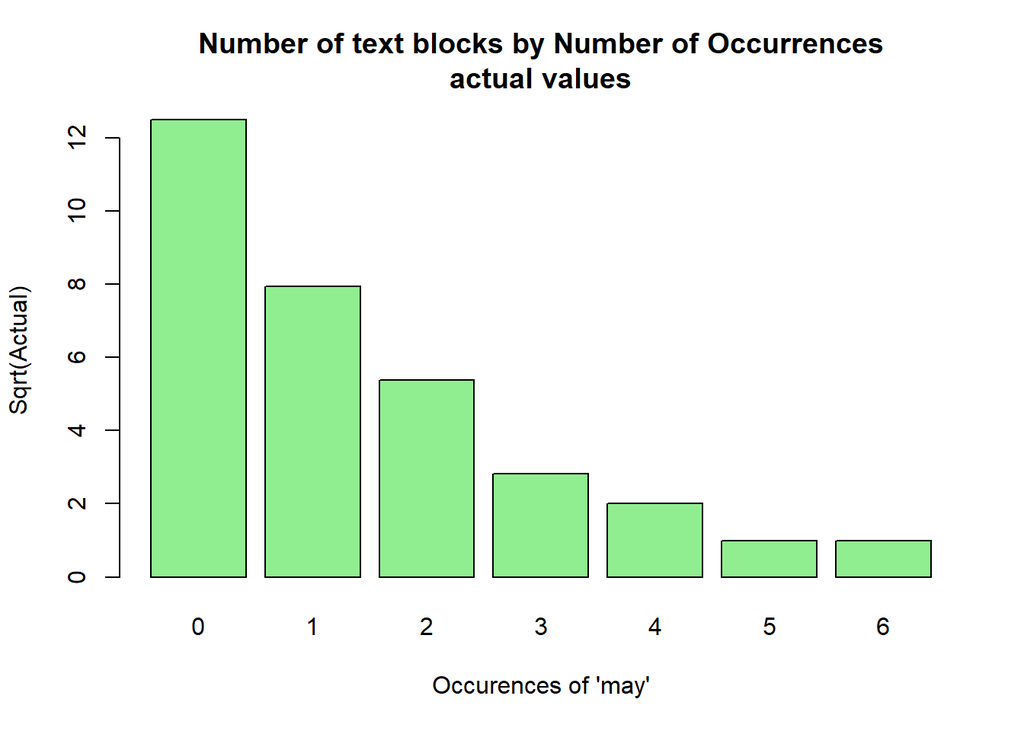

```r
barplot(sqrt(Federalist)
        , main = "Number of text blocks by Number of Occurrences\nactual values"
        , xlab = "Occurences of 'may'"
        , ylab = "Sqrt(Actual)"
        , col = "lightgreen"
)
```

Use the goodfit function in the vcd package to estimate the parameters and compare the fit of different distributions. It provides hanging rootograms that are intuitive views of discrete goodness of fit testing.

First, a Poisson fit using maximum likelihood - exactly what we’ve just done, but with bells on it:

```r
Fed_fit0 <- goodfit(Federalist, type = "poisson")
# This will show the rate parameter, estimated by Maximum Likelihood
# This estimate is the same as the naive mean. This is to be expected when fitting a poisson.
unlist(Fed_fit0$par)
```

```
##    lambda
## 0.6564885
```

```r
# This will show a Chi-Square Goodness of fit test against the expected values of a poisson distribution with this parameter
summary(Fed_fit0)
```

```
##
##   Goodness-of-fit test for poisson distribution
##
##                       X^2 df     P(> X^2)
## Likelihood Ratio 25.24312  5 0.0001250511
```

The $\chi^2$ test is very strong evidence to reject the null hypothesis. This sample is not from a Poisson distribution with rate = sample mean. However, we don’t know much about what caused this result. However, the rootogram plot makes it very clear what the problem is by showing how the variable diverges from the expectations.

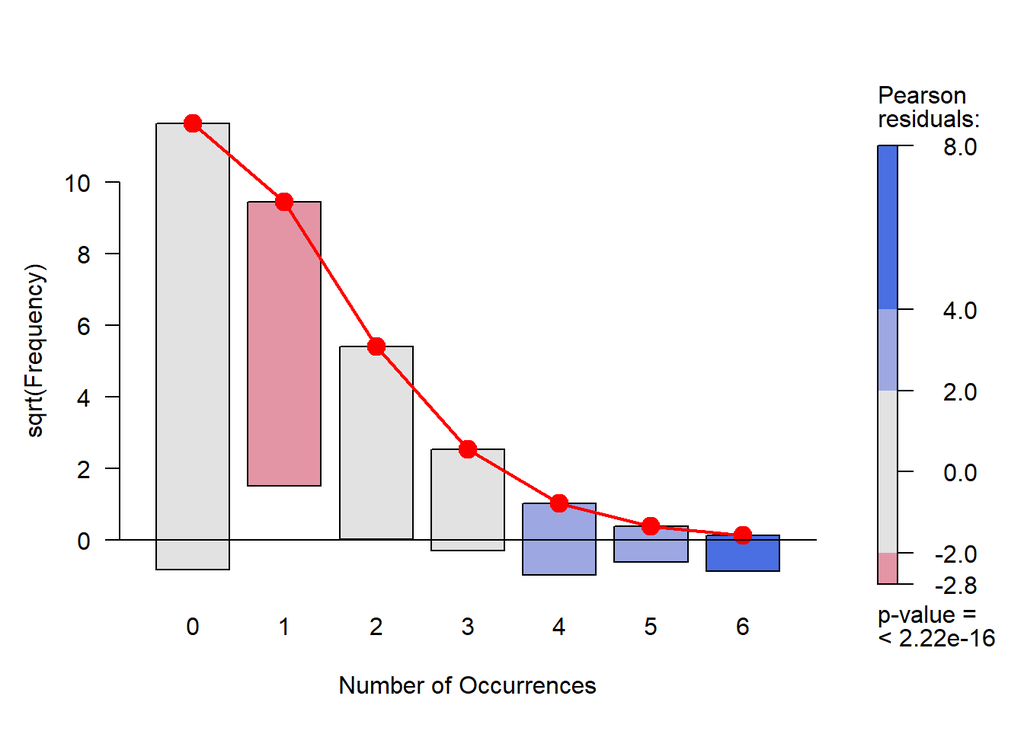

```r
plot(Fed_fit0, type = "hanging", shade = TRUE)
```

By hanging each bar top down from the expected distribution, we just need to look at how the bottoms of the bars miss the $y = 0$ reference line. This is visually much more intuitive than comparing the tops of the bars to a curve. The contribution of each bar to the $\chi^2$ statistic is also made clear by the shading.

We can try fitting a Poisson using a different estimation method, minimising the $\chi^2$ errors instead:

```r
Fed_fit0 <- goodfit(Federalist, type = "poisson", method = "MinChisq")
# This has found a different value for the rate parameter.
unlist(Fed_fit0$par)
```

```
##    lambda
## 0.8236976
```

```r
# This will show a Chi-Square Goodness of fit test against the expected values of a poisson distribution with this parameter
summary(Fed_fit0)
```

```
##
##   Goodness-of-fit test for poisson distribution
##
##              X^2 df     P(> X^2)
## Pearson 46.86767  5 6.045556e-09
```

The $\chi^2$ test is also very strong evidence against the null.

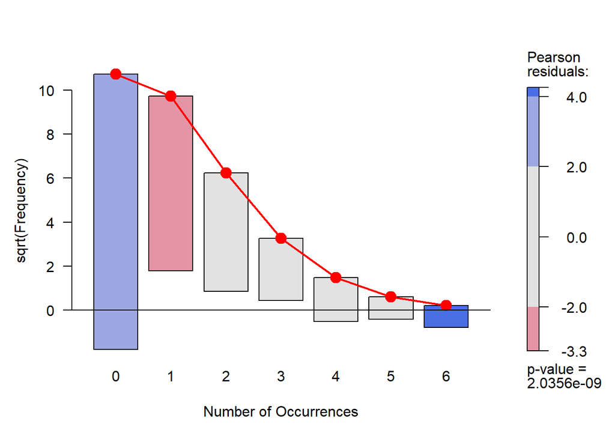

```r
plot(Fed_fit0, type = "hanging", shade = TRUE)
```

The rootogram shows that the residuals have just been shuffled around so they balance better by sign. Clearly Poisson is not the right choice.

Next, fit a negative binomial fit:

```r
Fed_fit1 <- goodfit(Federalist, type = "nbinomial")
# This will show the rate and dispersion parameters, estimated by Maximum Likelihood
# prob is the rate. Here it's very close to the poisson mean
# size is the dispersion
unlist(Fed_fit1$par)
```

```
##      size      prob
## 1.1863297 0.6437582
```

```r
summary(Fed_fit1)
```

```
##
##   Goodness-of-fit test for nbinomial distribution
##
##                       X^2 df  P(> X^2)
## Likelihood Ratio 1.964028  4 0.7423751
```

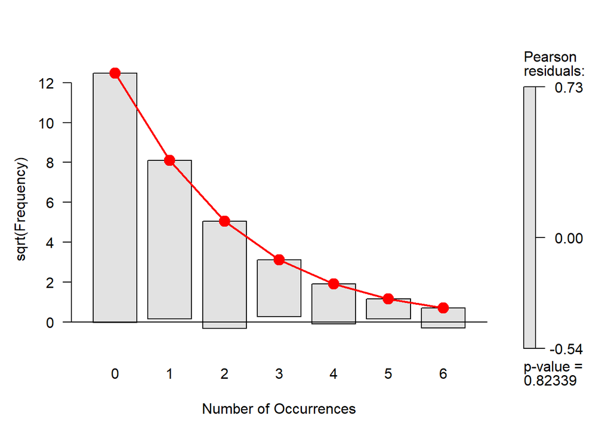

```r
plot(Fed_fit1, type = "hanging", shade = TRUE)
```

We have estimated some parameters and the $\chi^2$ goodness of fit test result is not significant. We accept that null hypothesis that this sample is from a negative binomial distribution having the estimated parameters. The plot speaks for itself now that the bars drop close to the $y = 0$ reference line, with only insignificant residuals.

We will now assess a different body of text.

```r
# Some dummy data
nonFederalist <- structure(c(135L, 71L, 36L, 17L, 8L, 4L, 1L), .Dim = 7L, .Dimnames = structure(list(
    c("0", "1", "2", "3", "4", "5", "6")), .Names = "nMay"), class = "table")
nonFederalist
```

```
## nMay
##   0   1   2   3   4   5   6
## 135  71  36  17   8   4   1
```

```r
sum(nonFederalist) # number of blocks
```

```
## [1] 272
```

```r
sum(expand.dft(as.data.frame(nonFederalist))$nMay) # number of occurences
```

```
## [1] 252
```

```r
mean(expand.dft(as.data.frame(nonFederalist))$nMay)
```

```
## [1] 0.9264706
```

```r
var(expand.dft(as.data.frame(nonFederalist))$nMay)
```

```
## [1] 1.470588
```

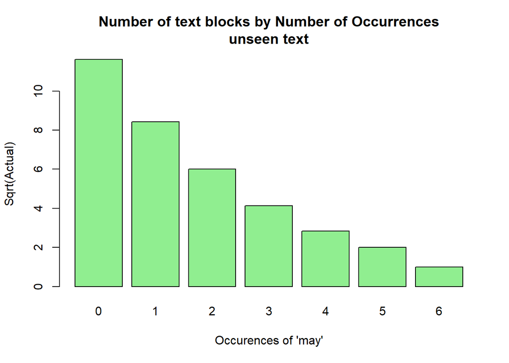

```r
barplot(sqrt(nonFederalist)
        , main = "Number of text blocks by Number of Occurrences\nunseen text"
        , xlab = "Occurences of 'may'"
        , ylab = "Sqrt(Actual)"
        , col = "lightgreen"
)
```

The descriptive statistics are a bit larger than Federalist, but is this significant? We can test it properly using the parameters from the goodfit object we just created:

```r
# we pass in our fitted parameter list this time
Fed_fit3 <- goodfit(nonFederalist, type = "nbinomial", par = Fed_fit1$par)
summary(Fed_fit3)
```

```
##
##   Goodness-of-fit test for nbinomial distribution
##
##                       X^2 df    P(> X^2)
## Pearson          22.41764  6 0.001016934
## Likelihood Ratio 19.51130  6 0.003381872
```

The $\chi^2$ result is significant, and strong evidence that this new text is not from the same distribution. However, on it’s own, the test can’t provide detailed information.

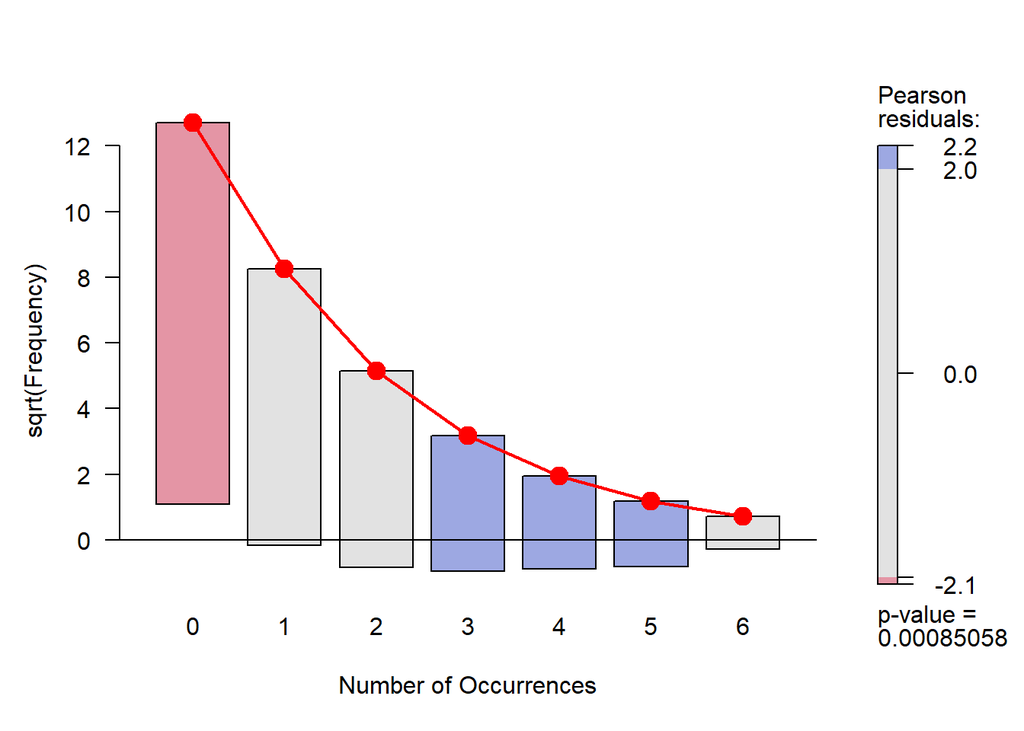

```r
plot(Fed_fit3, type = "hanging", shade = TRUE)
```

The rootogram hangs the frequency bars off the expected distribution, which this time is fixed with parameters we estimated on the original text. We can now see from the pattern of residuals that the word ‘may’ seems to appear more frequently in this text. Specifically, the tail, with 3-5 occurrences per 200 words is fatter, while blocks where this word is absent are fewer.

### 3.5.2 Talking points

- Does this test imply that the second text was not written by the same author?
- Text analysis has come a long way since these statistical techniques were developed. What are some newer, more sophisticated methods?
- Can you describe, in plain English, what is the implication of finding a Poisson distributed word frequency? Why is the negative binomial a more natural distribution for word frequency? Hints:
  - Frequency is the number of times the word appeared per block of 200 words
  - Review the notes about these two distributions at the top of this task

# 4 Summary

- We have demonstrated some classical statistical techniques that are not usually included in a basic stats curriculum.
- We have discussed how these techniques can be applied to tasks that are typical in many practical Machine Learning projects.
  - Text/Event Analysis
  - Comparing True and Predicted Classes for Ordinal data
  - Exploratory Data Analysis
  - Dimension Reduction and Clustering
- We have shown that simple R functions and visual analyses are extremely powerful and you don’t have to dive deep into stats to get the benefits.
- Nearly all the resources you need to take the next steps yourself are available in the “vcd” and “vcdExtra” package for R, R~/vignette(“vcd”)
- If you want to go much, much deeper with these topics, [Michael Friendly’s book](https://www.crcpress.com/Discrete-Data-Analysis-with-R-Visualization-and-Modeling-Techniques-for/Friendly-Meyer/p/book/9781498725835) pulls together decades of research in this field and is a one-stop reference for this branch of statistics.

In our rush to use the latest developments and technologies in Machine Learning and Deep Learning, it’s easy forget that none of it would be possible without pioneering statistical research of previous decades. Most of this work is still relevant to everyday problems in Machine Learning practice, and it’s always worth a review of the foundations before reaching for the newest tools.

Above all, never under-estimate the power of visual analytics. A well thought out plot can save you paragraphs of explanation.